# 1-phase VSI

The single phase inverter given below is operated such that the voltage across RL load is a $100\,$Hz square wave. The circuit parameters are $R=1\,\Omega$, $L=10\,$mH, $V_{dc}=100\,$V. What is the average current through the dc voltage source?

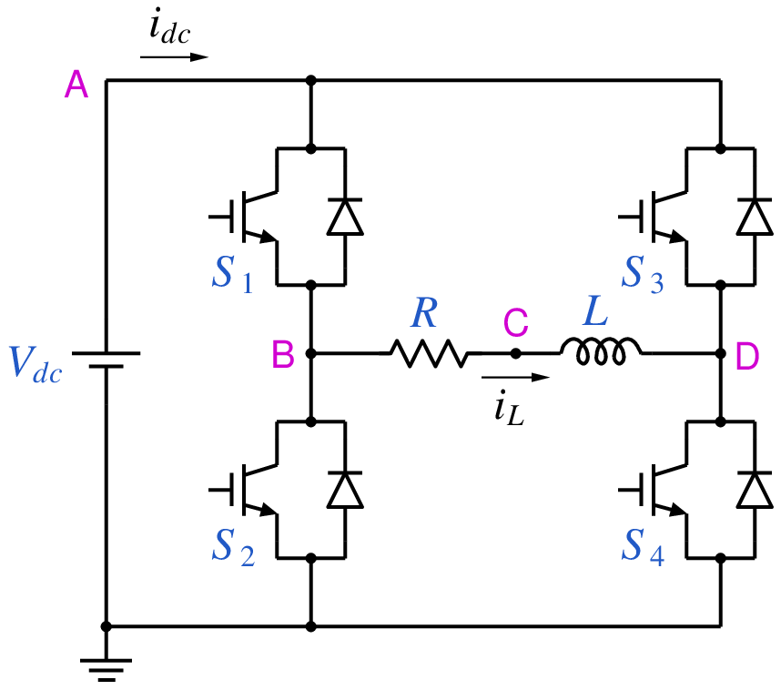

```python
from IPython.display import Image
Image(filename =r'VSI_1ph_14_fig_1.png', width=300)
```

```python
# run this cell to view the circuit file.
%pycat VSI_1ph_14_orig.in
```

We now replace the strings such as \$Vdc, \$L, with the values of our choice by running the python script given below. It takes an existing circuit file `VSI_1ph_14_orig.in` and produces a new circuit file `VSI_1ph_14.in`, after replacing \$Vdc, \$L, etc. with values of our choice.

```python
import gseim_calc as calc
s_Vdc = '100'
s_R = '1'
s_L = '10e-3'

s_f_hz = "100.0"
f_hz = float(s_f_hz)

T = 1/f_hz
s_Tby2 = "%11.4E"%(T/2)

l = [
  ('$Vdc', s_Vdc),
  ('$R', s_R),
  ('$L', s_L),
  ('$f_hz', s_f_hz),
  ('$Tby2', s_Tby2)
]
calc.replace_strings_1("VSI_1ph_14_orig.in", "VSI_1ph_14.in", l)
print('VSI_1ph_14.in is ready for execution')
```

```
VSI_1ph_14.in is ready for execution
```

**Execute the following cell to run GSEIM on VSI_1ph_14.in.**

```python
import os
import dos_unix
# uncomment for windows:
#dos_unix.d2u("VSI_1ph_14.in")
os.system('run_gseim VSI_1ph_14.in')
```

```
Circuit: filename = VSI_1ph_14.in
main: calling solve_sss
solve_sss starting: sss_n_st: 1
solve_sss_ex: sss_iter_newton=0, rhs_sss_norm=2.1107e+01, sss_period_1_compute=2.0000e-02
solve_sss_ex: sss_iter_newton=1, rhs_sss_norm=2.9132e-13, sss_period_1_compute=2.0000e-02
solve_sss_ex: calling sss_solve_trns_ex for one more trns step
Transient simulation starts...
i=0
GSEIM: Program completed.
```

```
0
```

The circuit file (`VSI_1ph_14.in`) is created in the same directory as that used for launching Jupyter notebook. The last step (i.e., running `GSEIM` on `VSI_1ph_14.in`) creates a data file called `VSI_1ph_14.dat`in the same directory. We can now use the python code below to compute/plot the various quantities of interest.

```
filename: VSI_1ph_14.dat
average source current:  2.0259E+00
rms source current:  1.4223E+01
rms load current:  1.4223E+01
peak load current:  2.4436E+01
power delivered to load:  2.0230E+02
```

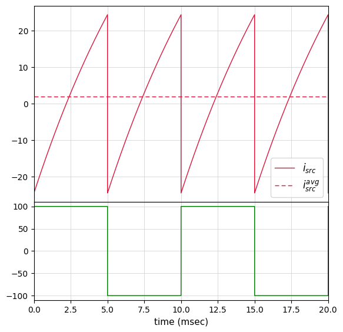

```python
import numpy as np
import matplotlib.pyplot as plt
import gseim_calc as calc
from setsize import set_size

slv = calc.slv("VSI_1ph_14.in")

i_slv = 0
i_out = 0
filename = slv.l_filename_all[i_slv][i_out]
print('filename:', filename)
u = np.loadtxt(filename)
t1 = u[:, 0]
t = 1e3*t1 # convert time to msec

v_out = slv.get_array_double(i_slv,i_out,"v_out",u)
IR    = slv.get_array_double(i_slv,i_out,"IR"   ,u)
ISrc  = slv.get_array_double(i_slv,i_out,"ISrc" ,u)
P_R   = slv.get_array_double(i_slv,i_out,"P_R"  ,u)
g1    = slv.get_array_double(i_slv,i_out,"g1"   ,u)
g2    = slv.get_array_double(i_slv,i_out,"g2"   ,u)

# since we have stored two cycles, we need to divide the last time point
# by 2 to get the period:

T = t[-1]/2

l_IR   = calc.avg_rms_3a(t, IR  , 0.0, 2.0*T, 1.0e-4*T)
l_P_R  = calc.avg_rms_3a(t, P_R , 0.0, 2.0*T, 1.0e-4*T)
l_ISrc = calc.avg_rms_3a(t, ISrc, 0.0, 2.0*T, 1.0e-4*T)

l_IR_1 = calc.min_max_1(t, IR, 0.0, 2.0*T)

print('average source current:', "%11.4E"%l_ISrc[0])
print('rms source current:', "%11.4E"%l_ISrc[1])
print('rms load current:', "%11.4E"%l_IR[1])
print('peak load current:', "%11.4E"%l_IR_1[1])
print('power delivered to load:', "%11.4E"%l_P_R[0])

color1='green'
color2='crimson'
color3='goldenrod'
color4='blue'

fig, ax = plt.subplots(2, sharex=False, gridspec_kw={'height_ratios': [2, 1]})
plt.subplots_adjust(wspace=0, hspace=0.0)

set_size(5, 5, ax[0])

for k in range(2):
    ax[k].grid(color='#CCCCCC', linestyle='solid', linewidth=0.5)
    ax[k].set_xlim(left=0.0, right=2.0*T)

ax[0].tick_params(labelbottom=False)

ax[0].plot(t, ISrc, color=color2, linewidth=1.0, label="$i_{src}$")
ax[0].axhline(y=l_ISrc[0], color=color2, linewidth=1.0, label="$i_{src}^{avg}$", linestyle='--', dashes=(5,3))

ax[1].plot(t, v_out, color=color1, linewidth=1.0, label="$V_o$")

ax[1].set_xlabel('time (msec)', fontsize=11)

ax[0].legend(loc = 'lower right',frameon = True, fontsize = 10, title = None,
   markerfirst = True, markerscale = 1.0, labelspacing = 0.5, columnspacing = 2.0,
   prop = {'size' : 12},)

#plt.tight_layout()
plt.show()
```

This notebook was contributed by **Prof. Nakul Narayanan K**, Govt. Engineering College, Thrissur. He may be contacted at nakul@gectcr.ac.in.